# Analysis of Perspectives on Abortion Through the Decades: Social and Political Influences

Anh Tu Pham

### Introduction

Throughout history, abortion has always been a controversial topic and poses many challenges to society, medical field and politics. Opinions about abortion are not only personal, but are influenced by a range of factors – from culture and religion, to education and politics.  
Why do some people support women's right to choose in abortion while others feel that it is an unacceptable action? Are there differences between populations based on race, sex or education level? And most importantly, how have these perspective changed over the decade?

##### **Background**

Abortion has a complicated history, with many viewing it through moral, religious or individual authority. While some argue that every woman has the right to make decisions about her body, others argue that this decisions should be limited. Although much progress has been made in reducing risks and improving the quality of health services, views on abortion have not changed much.

##### **In this tutorial, we will**

- Explores changing attitudes about abortion over the decades.
- Analyze differences between groups based on race, gender, political party, and academic background.
- Pose and test assumptions about the influence of social and political factors on attitudes about abortion.
- Use machine learning models to predict an individual's opinion based on their personal information.

Let's explore and gain insight into one of the most controversial topics in modern society.

### Data Collection

##### **Data Source**

This data was collected from the overall social survey and was shared on Kaggle at the following address: [Abortion Opinions in the General Social Survey](https://www.kaggle.com/datasets/utkarshx27/abortion-opinions-in-the-general-social-survey). This is a survey conducted annually to gather information on public opinion and opinion on various social issues, including views on abortion.

##### **Data description**

The General Social Survey is a social survey conducted annually in the United States that collects information about the public's views, attitudes, and behaviors on a wide range of social issues. The data includes surveys from 1972.

```python
#import libraries
import matplotlib.pyplot as plt
import pandas as pd
import seaborn as sns
```

```python
# Load the dataset
data = pd.read_csv("gss_abortion.csv")

# Display the first few rows of the dataset
data.head(10)
```

|  | Unnamed: 0 | id | year | age | race | sex | hispaniccat | educ | partyid | relactiv | abany | abdefect | abnomore | abhlth | abpoor | abrape | absingle | pid | hispanic |
| --- | --- | --- | --- | --- | --- | --- | --- | --- | --- | --- | --- | --- | --- | --- | --- | --- | --- | --- | --- |
| 0 | 1 | 1 | 1972 | 23.0 | White | Female | NaN | 16.0 | Ind,Near Dem | NaN | NaN | 1.0 | 1.0 | 1.0 | 1.0 | 1.0 | 1.0 | 2.0 | NaN |
| 1 | 2 | 2 | 1972 | 70.0 | White | Male | NaN | 10.0 | Not Str Democrat | NaN | NaN | 1.0 | 0.0 | 1.0 | 0.0 | 1.0 | 1.0 | 1.0 | NaN |
| 2 | 3 | 3 | 1972 | 48.0 | White | Female | NaN | 12.0 | Independent | NaN | NaN | 1.0 | 1.0 | 1.0 | 1.0 | 1.0 | 1.0 | 3.0 | NaN |
| 3 | 4 | 4 | 1972 | 27.0 | White | Female | NaN | 17.0 | Not Str Democrat | NaN | NaN | 0.0 | 0.0 | 1.0 | 1.0 | 1.0 | 1.0 | 1.0 | NaN |
| 4 | 5 | 5 | 1972 | 61.0 | White | Female | NaN | 12.0 | Strong Democrat | NaN | NaN | 1.0 | 1.0 | 1.0 | 1.0 | 1.0 | 1.0 | 0.0 | NaN |
| 5 | 6 | 6 | 1972 | 26.0 | White | Male | NaN | 14.0 | Ind,Near Dem | NaN | NaN | 1.0 | 1.0 | 1.0 | 1.0 | 1.0 | 1.0 | 2.0 | NaN |
| 6 | 7 | 7 | 1972 | 28.0 | White | Male | NaN | 13.0 | Ind,Near Dem | NaN | NaN | 1.0 | 0.0 | 1.0 | 0.0 | 1.0 | 1.0 | 2.0 | NaN |
| 7 | 8 | 8 | 1972 | 27.0 | White | Male | NaN | 16.0 | Ind,Near Dem | NaN | NaN | 1.0 | 1.0 | 1.0 | 1.0 | 1.0 | 1.0 | 2.0 | NaN |
| 8 | 9 | 9 | 1972 | 21.0 | Black | Female | NaN | 12.0 | Strong Democrat | NaN | NaN | 1.0 | 0.0 | 1.0 | 0.0 | NaN | 0.0 | 0.0 | NaN |
| 9 | 10 | 10 | 1972 | 30.0 | Black | Female | NaN | 12.0 | Strong Democrat | NaN | NaN | 1.0 | 0.0 | 1.0 | 1.0 | 1.0 | 0.0 | 0.0 | NaN |

### Data Processing

Before we start analyzing the data, the first thing we need to do is clean and prepare the data. Raw data often contains many errors and is not uniform. To have an accurate and reliable view of the data, we need to preprocess it carefully.

##### **Handling columns with a high percentage of missing data**

Based on the percentage of missing data, we will remove columns with too high a missing rate, such as hispaniccat, relactiv, and hispanic.

```python
# Drop columns with high percentage of missing values
columns_to_drop = ['hispaniccat', 'relactiv', 'hispanic']
data_cleaned = data.drop(columns=columns_to_drop)

# Check the shape of the cleaned data
data_cleaned.shape
```

```
(64814, 16)
```

Data after being cleaned has 16 columns (compared to the original 19 columns).

##### **Fill in the missing data**

For columns with a low percentage of missing data, we will fill in the missing value. For numeric data, we will use the mean, and for category data, we will use the value that occurs most often.

```python
# Fill missing values for numeric columns with the mean
numeric_columns = ['age', 'educ', 'pid']
for column in numeric_columns:
    mean_value = data_cleaned[column].mean()
    data_cleaned[column].fillna(mean_value, inplace=True)

# Fill missing values for categorical columns with the mode
categorical_columns = ['partyid']
for column in categorical_columns:
    mode_value = data_cleaned[column].mode()[0]
    data_cleaned[column].fillna(mode_value, inplace=True)

# Check if there are any missing values left
remaining_missing = data_cleaned.isnull().sum()
remaining_missing
```

```
Unnamed: 0        0
id                0
year              0
age               0
race              0
sex               0
educ              0
partyid           0
abany         28020
abdefect      20662
abnomore      20742
abhlth        20454
abpoor        20791
abrape        20892
absingle      20794
pid               0
dtype: int64
```

After processing, we removed most of the missing data, except for the columns related to the abortion opinion (abany, abdefect, abnomore, abhlth, abpoor, abrape, absingle). These columns still have some fairly large missing values.

Due to the nature of this data (regarding personal opinions), filling in the missing values may not accurately reflect the opinions of the respondents. A common choice in this case is to keep the missing data intact and deal with them during analysis, e.g. when plotting or building models.

##### **Standardized data**

We will convert the catalog data into numeric form for easy analysis.

```python
# Convert categorical data to numeric using label encoding
from sklearn.preprocessing import LabelEncoder

label_encoders = {}
for column in ['race', 'sex', 'partyid']:
    le = LabelEncoder()
    data_cleaned[column] = le.fit_transform(data_cleaned[column])
    label_encoders[column] = le

# Display the first few rows of the processed data
data_cleaned.head(10)
```

[output not shown]

We have converted the catalog data to numeric form. Specifically:  
The race column has been converted to numeric values.  
The sex column has been converted to numeric values (0 for Female and 1 for Male).  
The partyid column has also been converted to numeric values.  
With this data processing, we are done with the data processing and ready to proceed with the analysis.

**Group data by year**: To analyze views on abortion by decade, we need to group the data by year. We'll average out the columns related to abortion opinion to get an overview of people's thoughts for each year.

```python
# Group by year and calculate the mean for abortion-related columns
abortion_columns = ['abany', 'abdefect', 'abnomore', 'abhlth', 'abpoor', 'abrape', 'absingle']
grouped_data = data_cleaned.groupby('year')[abortion_columns].mean()

grouped_data.head(10)
```

| year | abany | abdefect | abnomore | abhlth | abpoor | abrape | absingle |
| --- | --- | --- | --- | --- | --- | --- | --- |
| 1972 | NaN | 0.785714 | 0.397251 | 0.869396 | 0.487724 | 0.791005 | 0.435419 |
| 1973 | NaN | 0.844945 | 0.476944 | 0.922764 | 0.534341 | 0.835286 | 0.491034 |
| 1974 | NaN | 0.851389 | 0.469171 | 0.924242 | 0.547636 | 0.864789 | 0.500704 |
| 1975 | NaN | 0.831711 | 0.457223 | 0.906832 | 0.531780 | 0.836850 | 0.482320 |
| 1976 | NaN | 0.839396 | 0.461645 | 0.907787 | 0.530683 | 0.836806 | 0.502782 |
| 1977 | 0.377282 | 0.854741 | 0.465116 | 0.905242 | 0.533829 | 0.837985 | 0.497601 |
| 1978 | 0.332884 | 0.819639 | 0.403237 | 0.906166 | 0.473792 | 0.831870 | 0.411405 |
| 1980 | 0.411095 | 0.830867 | 0.471215 | 0.901330 | 0.517045 | 0.834160 | 0.484330 |
| 1982 | 0.385227 | 0.821408 | 0.458310 | 0.903889 | 0.489566 | 0.838983 | 0.455215 |
| 1983 | 0.342574 | 0.788639 | 0.389474 | 0.897368 | 0.436629 | 0.828457 | 0.393838 |

The data have been grouped by year, and we have averaged the columns related to opinion on abortion. The mean for each column represents the percentage of people who supported abortion based on a specific reason in each year.  
Specifically, the values in the abdefect column represent the percentage of people in favor of abortion when a fetus with a malformation is found, and similarly for the other columns.

##### **Convert data to percentage**

We will convert the data to percentage form to facilitate later analysis and visualization.

```python
# Convert the grouped data to percentage format
grouped_data_percentage = grouped_data * 100

grouped_data_percentage.head(10)
```

| year | abany | abdefect | abnomore | abhlth | abpoor | abrape | absingle |
| --- | --- | --- | --- | --- | --- | --- | --- |
| 1972 | NaN | 78.571429 | 39.725131 | 86.939571 | 48.772395 | 79.100529 | 43.541944 |
| 1973 | NaN | 84.494536 | 47.694425 | 92.276423 | 53.434066 | 83.528601 | 49.103448 |
| 1974 | NaN | 85.138889 | 46.917080 | 92.424242 | 54.763585 | 86.478873 | 50.070423 |
| 1975 | NaN | 83.171071 | 45.722300 | 90.683230 | 53.177966 | 83.684951 | 48.231966 |
| 1976 | NaN | 83.939602 | 46.164478 | 90.778689 | 53.068340 | 83.680556 | 50.278164 |
| 1977 | 37.728195 | 85.474109 | 46.511628 | 90.524194 | 53.382950 | 83.798502 | 49.760110 |
| 1978 | 33.288410 | 81.963928 | 40.323668 | 90.616622 | 47.379170 | 83.187036 | 41.140530 |
| 1980 | 41.109531 | 83.086681 | 47.121535 | 90.132960 | 51.704545 | 83.416017 | 48.433048 |
| 1982 | 38.522727 | 82.140845 | 45.830970 | 90.388889 | 48.956571 | 83.898305 | 45.521542 |
| 1983 | 34.257426 | 78.863937 | 38.947368 | 89.736842 | 43.662906 | 82.845745 | 39.383791 |

The data has been converted to percentage form. Now, we can easily understand that, for example, in 1973, about 84.5% of people surveyed were in favor of abortion when the fetus had a defect (abdefect column).  
The next steps in data processing may include normalizing the data (especially when we want to use machine learning models) or performing other transformations based on the requirements of the analysis.

### Exploratory Analysis & Data Visualization

##### **Visualize views on abortion by decade**

We'll begin by visualizing the decade-by-decade shift in attitudes toward abortion. This helps us understand the trends and fluctuations of public opinion over the years.  
We will draw a line chart to show the percentage of people who support abortion based on different reasons from 1972 to 2018.

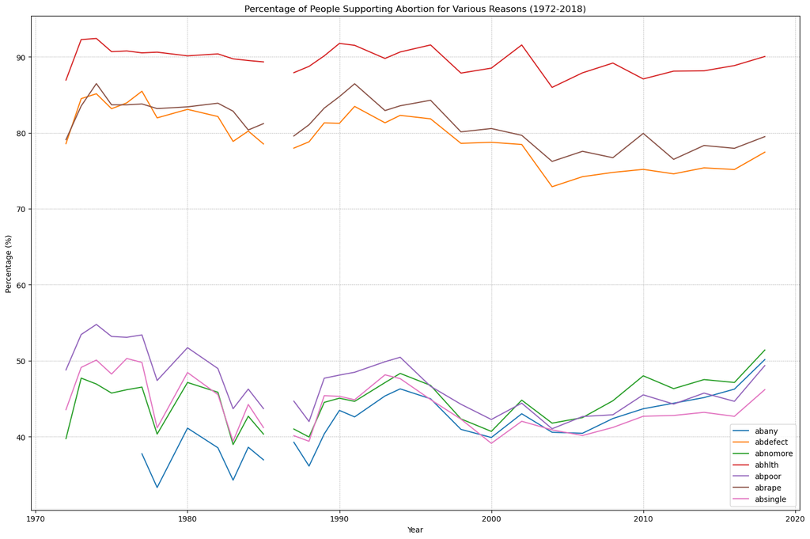

```python
import matplotlib.pyplot as plt
# Plotting the data
plt.figure(figsize=(15, 10))
for column in abortion_columns:
    plt.plot(grouped_data_percentage.index, grouped_data_percentage[column], label=column)

plt.title('Percentage of People Supporting Abortion for Various Reasons (1972-2018)')
plt.xlabel('Year')
plt.ylabel('Percentage (%)')
plt.legend(loc='best')
plt.grid(True, which='both', linestyle='--', linewidth=0.5)
plt.tight_layout()
plt.show()
```

##### **Visualize change of opinion based on political party**

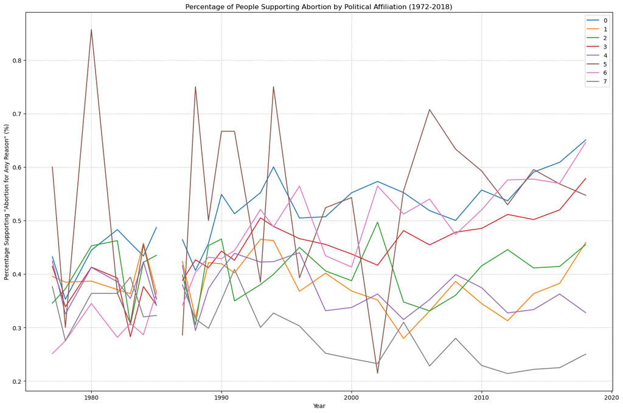

```python
# Group data by year and party affiliation, then calculate the mean for abortion-related columns
party_grouped = data_cleaned.groupby(['year', 'partyid'])[abortion_columns].mean().reset_index()

# Plotting the data
plt.figure(figsize=(15, 10))
parties = label_encoders['partyid'].classes_

# Plotting for each party
for idx, party in enumerate(parties):
    party_data = party_grouped[party_grouped['partyid'] == idx]
    plt.plot(party_data['year'], party_data['abany'], label=party)

plt.title('Percentage of People Supporting Abortion by Political Affiliation (1972-2018)')
plt.xlabel('Year')
plt.ylabel('Percentage Supporting "Abortion for Any Reason" (%)')
plt.legend(loc='best')
plt.grid(True, which='both', linestyle='--', linewidth=0.5)
plt.tight_layout()
plt.show()
```

##### **Visualize changing attitudes based on gender**

We can also consider the difference of opinion between men and women. We will use a stacked bar chart to show the change in opinion over the years between men and women.

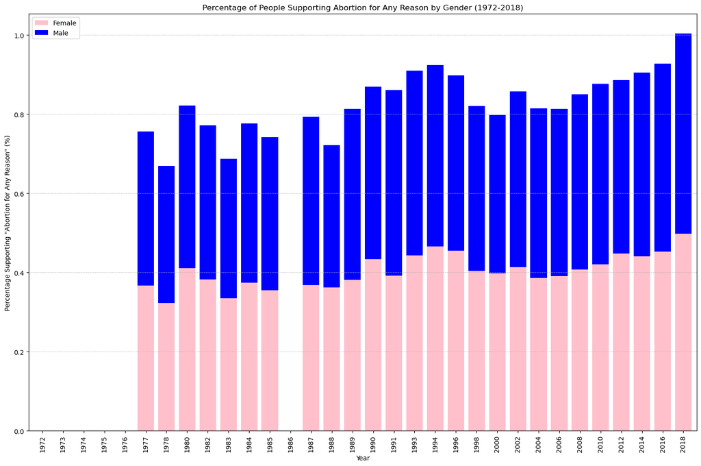

```python
# Group data by year and sex, then calculate the mean for the column 'abany'
sex_grouped = data_cleaned.groupby(['year', 'sex'])['abany'].mean().unstack()

# Plotting the stacked bar chart
sex_grouped.plot(kind='bar', stacked=True, figsize=(15, 10), width=0.8, color=['pink', 'blue'])
plt.title('Percentage of People Supporting Abortion for Any Reason by Gender (1972-2018)')
plt.xlabel('Year')
plt.ylabel('Percentage Supporting "Abortion for Any Reason" (%)')
plt.legend(['Female', 'Male'], loc='upper left')
plt.grid(axis='y', linestyle='--', linewidth=0.5)
plt.tight_layout()
plt.show()
```

##### **Visualize changes in opinion based on age**

Another important factor influencing attitudes about abortion is age. We will look at how attitudes about abortion change based on the age of the respondents.  
We will use a heatmap to show the change of opinion each year based on different age groups.

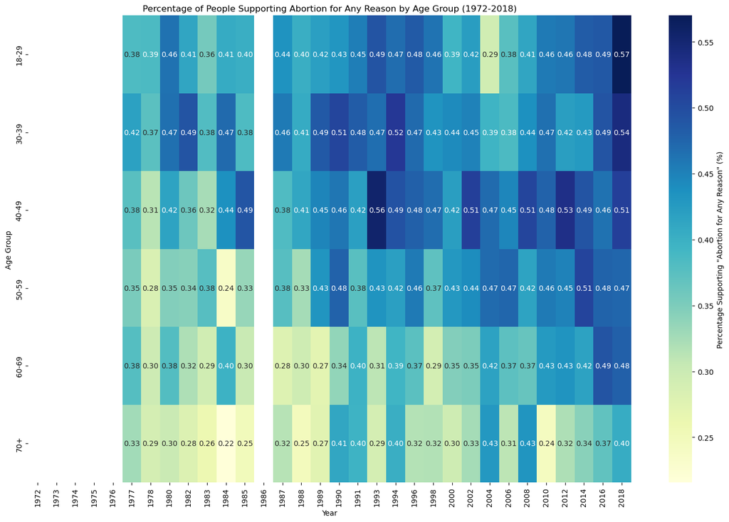

```python
import seaborn as sns

# Define age bins
bins = [18, 30, 40, 50, 60, 70, 80]
labels = ['18-29', '30-39', '40-49', '50-59', '60-69', '70+']

# Create age groups column
data_cleaned['age_group'] = pd.cut(data_cleaned['age'], bins=bins, labels=labels, right=False)

# Group data by year and age group, then calculate the mean for the column 'abany'
age_grouped = data_cleaned.groupby(['year', 'age_group'])['abany'].mean().unstack()

# Plotting the heatmap
plt.figure(figsize=(15, 10))
sns.heatmap(age_grouped.T, cmap='YlGnBu', annot=True, fmt=".2f", cbar_kws={'label': 'Percentage Supporting "Abortion for Any Reason" (%)'})
plt.title('Percentage of People Supporting Abortion for Any Reason by Age Group (1972-2018)')
plt.ylabel('Age Group')
plt.xlabel('Year')
plt.tight_layout()
plt.show()
```

##### **Visualize change in opinion based on race**

Another factor that can influence attitudes about abortion is race. We will look at how attitudes about abortion change based on the race of the respondents.  
We will use a line chart to show the change in opinion each year based on different racial groups.

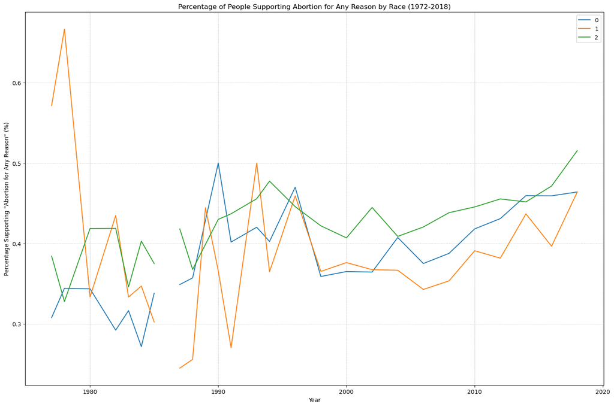

```python
# Group data by year and race, then calculate the mean for the column 'abany'
race_grouped = data_cleaned.groupby(['year', 'race'])['abany'].mean().unstack()

# Plotting the data
plt.figure(figsize=(15, 10))
races = label_encoders['race'].classes_

# Plotting for each race
for idx, race in enumerate(races):
    plt.plot(race_grouped.index, race_grouped[race], label=race)

plt.title('Percentage of People Supporting Abortion for Any Reason by Race (1972-2018)')
plt.xlabel('Year')
plt.ylabel('Percentage Supporting "Abortion for Any Reason" (%)')
plt.legend(loc='best')
plt.grid(True, which='both', linestyle='--', linewidth=0.5)
plt.tight_layout()
plt.show()
```

Some comments from the chart:

### Model: Analysis, Hypothesis Testing, & ML

##### Analysis

First, we will conduct some simple statistical analysis to look at the relationship between several variables.

##### Hypothesis testing

We will test the hypothesis that there is a significant difference in the pro-abortion ratio (abany column) between men and women. To do this, we will use the independent t-test. Hypothesis:

- H0: There is no difference between the percentage of men and women in supporting of abortion.
- H1: There is a difference between the proportion of men and women in supporting of abortion.

```python
from scipy.stats import ttest_ind

# Separate the data for males and females
male_data = data_cleaned[data_cleaned['sex'] == 1]['abany'].dropna()
female_data = data_cleaned[data_cleaned['sex'] == 0]['abany'].dropna()

# Conduct the independent t-test
t_stat, p_value = ttest_ind(male_data, female_data)

t_stat, p_value
```

```
(4.093100951647711, 4.265497497462698e-05)
```

The independent t test results show that:

- Statistical value t is 4.0931
- Statistical value p is 4.27e-05, means very small.

Since the p-value is smaller than the normal significance level (eg, 0.05), we reject the H0 hypothesis and conclude that there is a significant difference between the proportions in supporting of abortion among men and women.

##### **Machine learning**

We will build a machine learning model to predict views on abortion (abany) based on other factors such as age, gender, education level, and political party. We will use logistic regression model, since this is a binary classification problem.

```python
# Remove rows with NaN values in the training and test sets
train_indices = y_train.dropna().index
X_train_filled = X_train_filled.loc[train_indices]
y_train = y_train.dropna()

test_indices = y_test.dropna().index
X_test_filled = X_test_filled.loc[test_indices]
y_test = y_test.dropna()

# Create and train the model again
model = LogisticRegression(max_iter=1000)
model.fit(X_train_filled, y_train)

# Predict on the test set
y_pred = model.predict(X_test_filled)

# Calculate accuracy
accuracy = accuracy_score(y_test, y_pred)

# Generate a classification report
report = classification_report(y_test, y_pred, zero_division=1)

accuracy, report
```

[output not shown]

Finally, we have built and evaluated the machine learning model. Here are the results:

##### **Analyze the importance of features**

We will examine the importance of features in our machine learning model to better understand which features have the greatest influence on attitudes about abortion.  
We will use the coefficients of the logistic regression model to evaluate the importance of each feature.

```python
# Retrieve the coefficients of the features
coefficients = model.coef_[0]

# Combine feature names and their importance scores into a dataframe
feature_importance = pd.DataFrame({
    'Feature': features,
    'Importance': coefficients
}).sort_values(by='Importance', ascending=False)

feature_importance
```

|  | Feature | Importance |
| --- | --- | --- |
| 2 | educ | 0.151706 |
| 1 | sex | 0.037603 |
| 0 | age | -0.003945 |
| 3 | partyid | -0.058300 |

Here is the significance of the features according to our logistic regression model:

- edu: 0.1517
- sex: 0.0376
- age: -0.0039
- partyid: -0.0583 Some comments from the results:
- educ (education level) was the most important in predicting attitudes about abortion. This may suggest that people with higher education tend to be more supportive of abortion.
- partyid has a negative coefficient, meaning that people belonging to a particular political party tend not to support abortion. We can perform additional steps of analysis or hypothesis testing, or use other machine learning models such as decision trees or random forests to improve performance.

##### **Analyze the correlation between features**

To explore the relationship between features through the graph, we can use:

- Scatter plots: To examine the relationship between two continuous features.
- Bar or Box plots: To compare groups in a categorical feature and a continuous feature.
- Heatmap: To look at the correlation between many features at the same time.

The correlation between features tells us how related they are. This can help us better understand the data and feature selection for machine learning models.  
We will use the Pearson correlation matrix to examine the correlation between features. At the same time, we will visualize this correlation matrix through a heatmap.

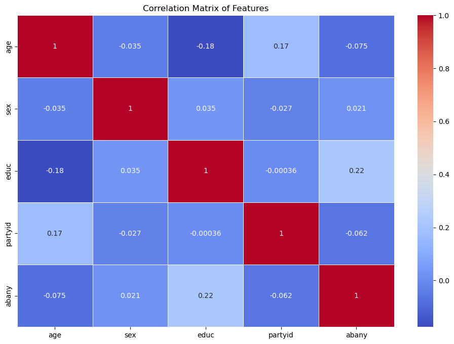

```python
import seaborn as sns

# Compute the correlation matrix
correlation_matrix = data_cleaned[features + ['abany']].corr()

# Plot the heatmap
plt.figure(figsize=(12, 8))
sns.heatmap(correlation_matrix, annot=True, cmap="coolwarm", linewidths=.5)
plt.title('Correlation Matrix of Features')
plt.show()
```

The above heatmap shows the correlation matrix between the features. Some comments from the chart:

- abany (abortion for any reason) has a small positive correlation with edu (education level). This may suggest that people with higher education are more likely to support abortion.
- abany has a small negative correlation with age and partyid. This may indicate that people who are older or belong to certain political parties are less likely to support abortion. Other features were not strongly correlated with each other or with abany.

Let's start by looking at the relationship between edu (education level) and abany (opinion on abortion) through a bar chart. This graph will show us the percentage of people who support abortion in each educational level group.

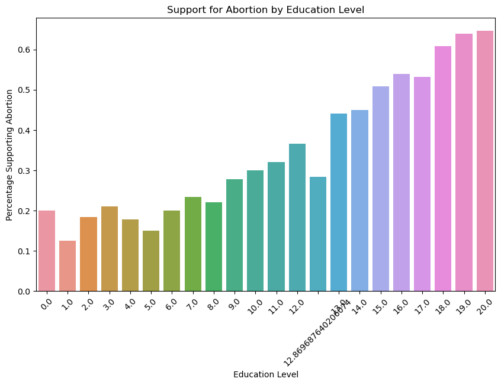

```python
# Group by education level and calculate the mean of 'abany' for each group
educ_abortion = data_cleaned.groupby('educ')['abany'].mean().reset_index()

# Plot
plt.figure(figsize=(10, 6))
sns.barplot(x='educ', y='abany', data=educ_abortion)
plt.title('Support for Abortion by Education Level')
plt.xlabel('Education Level')
plt.ylabel('Percentage Supporting Abortion')
plt.xticks(rotation=45)
plt.show()
```

Below is a bar chart showing support for abortion by education level:

- The x-axis represents educational attainment.
- The y-axis represents the percentage of people who support abortion.

We can see that support for abortion increases with education level. This matches the correlation results we saw earlier.  
We will continue to visualize the relationship between partyid and abany.

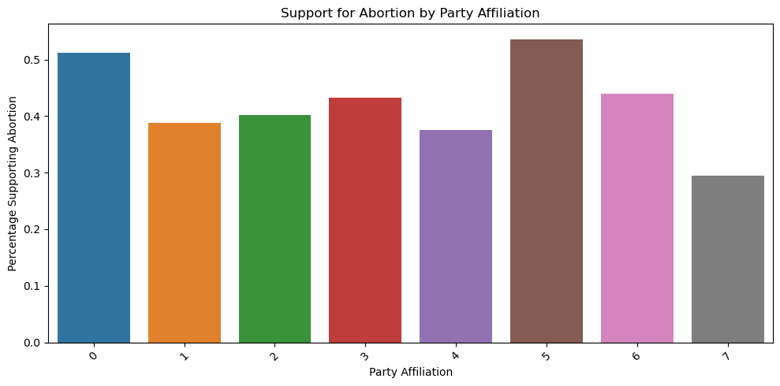

```python
# Group by party affiliation and calculate the mean of 'abany' for each group
party_abortion = data_cleaned.groupby('partyid')['abany'].mean().reset_index()

# Plot with a smaller figure size
plt.figure(figsize=(10, 5))
sns.barplot(x='partyid', y='abany', data=party_abortion)
plt.title('Support for Abortion by Party Affiliation')
plt.xlabel('Party Affiliation')
plt.ylabel('Percentage Supporting Abortion')
plt.xticks(rotation=45)
plt.tight_layout()
plt.show()
```

Here is a bar chart showing support for abortion based on political party:

- The x-axis represents the political party.
- The y-axis represents the percentage of people who support abortion. As we can see, the level of support for abortion varies depending on the political party.

### Interpretation: Insight & Policy Decision

##### **Summary of key findings**

One of the most important findings from the data is that people with more education tend to be more supportive of abortion. There are several possible explanations for this:

- People with more education can be exposed to a larger amount of information and from a wider variety of sources.
- They may have a stronger critical side and approach the issue from a more scientific perspective.
- Academic environments often encourage freedom of thought and personal choice.

In addition, Perspective on abortion are clearly influenced by political parties. This shows that the abortion issue is not only a medical issue but also a political one. This not only reflects differences in political thinking, but also shows the influence of culture and education within each party.

##### **Policy proposal**

Based on the above findings, we can make several policy recommendations:

- Strengthening education about women's reproductive health and choice. This can help people take a more thoughtful look and make decisions based on accurate information.
- Create communication campaigns to reduce polarization on the issue, by presenting information from both sides of the issue.
- Work with representatives from political parties to reach a consensus on policy regarding abortion.

##### **Limitations and future development directions**

Although we have made important findings from the data, it should be noted that there are limitations to this analysis:

- Data represents only some people and may not reflect the entire view of society.
- The machine learning models we used may not reflect the full complexity of the problem.

In the future, we can expand this study by collecting more data from a variety of sources and using more advanced analytical methods.

##### **Additional Learning Resources:**

[Educational Attainment and Women's Health](https://www.ncbi.nlm.nih.gov/pmc/articles/PMC4863279/)  
[Education and Views on Morality](https://www.pewresearch.org/religion/religious-landscape-study/)  
[How Political Parties Shape Attitudes Toward Abortion](https://www.jstor.org/stable/3791833)  
[Media Influence on Public Understanding of Science](https://pubmed.ncbi.nlm.nih.gov/16152830/)